# Práctica 16 — Regresión Lineal Múltiple

Data Science · Mayo 2026

Alejandro Panera Pascual

05 de mayo de 2026

# 1 Introducción

En esta práctica se aplica una **regresión lineal múltiple** sobre los datos del estudio PISA 2022 (muestra española). El objetivo es analizar qué factores explican el rendimiento en matemáticas, tomando como predictores la puntuación en lectura, el género del alumno y el nivel educativo de los padres.

La regresión lineal múltiple permite modelar la relación entre una variable dependiente cuantitativa ($Y$) y varios predictores ($X_1, X_2, \ldots, X_p$):

$$Y = \beta_0 + \beta_1 X_1 + \beta_2 X_2
+ \cdots + \beta_p X_p + \varepsilon$$

# 2 Carga de datos

```r
library(haven)

pisa <- read_sav("PISA22SP.sav")
pisa <- na.omit(pisa)

cat("Observaciones tras eliminar NAs:", nrow(pisa))
```

```
## Observaciones tras eliminar NAs: 22157
```

# 3 Exploración inicial

Antes de modelar, examinamos las variables que entrarán en el análisis.

```r
summary(pisa[, c("mates", "lectu", "heduc", "genero")])
```

```
##      mates           lectu           heduc            genero
##  Min.   :182.9   Min.   : 58.0   Min.   : 1.000   Min.   :1.000
##  1st Qu.:435.3   1st Qu.:430.1   1st Qu.: 7.000   1st Qu.:1.000
##  Median :492.9   Median :495.5   Median : 8.000   Median :1.000
##  Mean   :490.9   Mean   :491.8   Mean   : 7.546   Mean   :1.494
##  3rd Qu.:547.8   3rd Qu.:556.0   3rd Qu.: 9.000   3rd Qu.:2.000
##  Max.   :787.0   Max.   :830.8   Max.   :10.000   Max.   :2.000
```

# 4 Preparación de variables

```r
pisa$genero <- as.factor(pisa$genero)
levels(pisa$genero) <- c("mujer", "hombre")
```

Distribución de la variable dependiente (**matemáticas**):

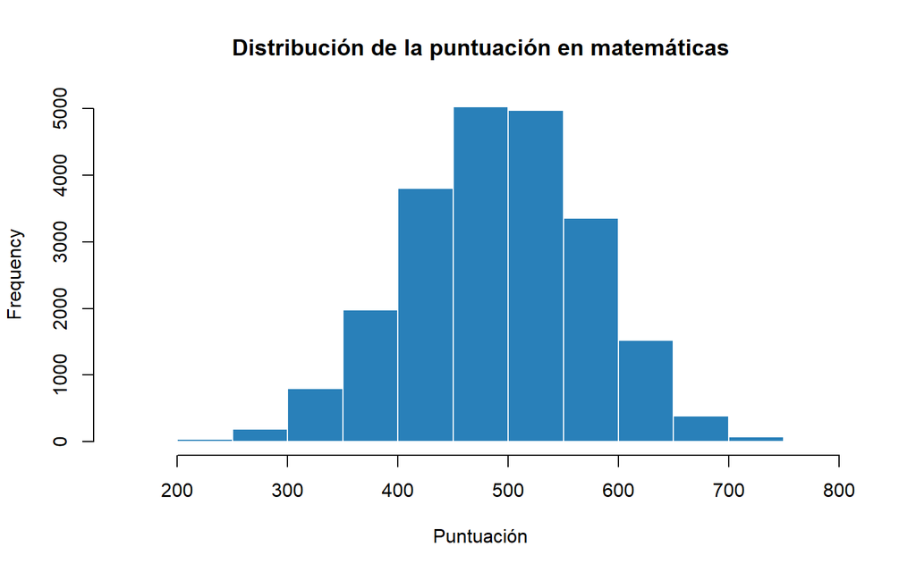

```r
hist(pisa$mates,
     main  = "Distribución de la puntuación en matemáticas",
     xlab  = "Puntuación",
     col   = "#2980b9",
     border = "white")
```

# 5 Regresión lineal simple

Como punto de partida, estudiamos la relación entre lectura y matemáticas de forma aislada.

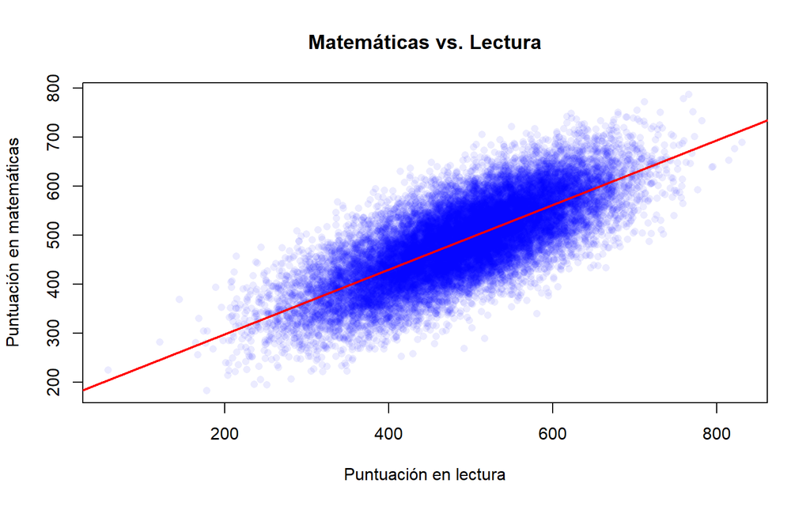

```r
plot(pisa$lectu, pisa$mates,
     main  = "Matemáticas vs. Lectura",
     xlab  = "Puntuación en lectura",
     ylab  = "Puntuación en matemáticas",
     col   = rgb(0, 0, 1, 0.08),
     pch   = 16)

reg_simple <- lm(mates ~ lectu, data = pisa)
abline(reg_simple, col = "red", lwd = 2)
```

```r
summary(reg_simple)
```

```
##
## Call:
## lm(formula = mates ~ lectu, data = pisa)
##
## Residuals:
##      Min       1Q   Median       3Q      Max
## -222.426  -36.941    0.012   36.469  199.756
##
## Coefficients:
##              Estimate Std. Error t value Pr(>|t|)
## (Intercept) 1.662e+02  1.970e+00   84.33   <2e-16 ***
## lectu       6.604e-01  3.937e-03  167.72   <2e-16 ***
## ---
## Signif. codes:  0 '***' 0.001 '**' 0.01 '*' 0.05 '.' 0.1 ' ' 1
##
## Residual standard error: 54.23 on 22155 degrees of freedom
## Multiple R-squared:  0.5594, Adjusted R-squared:  0.5594
## F-statistic: 2.813e+04 on 1 and 22155 DF,  p-value: < 2.2e-16
```

**Interpretación:** El coeficiente de `lectu` (~0.66) indica que por cada punto adicional en lectura, la nota en matemáticas aumenta ~0.66 puntos. El R² ≈ 0.56 muestra que la lectura por sí sola explica el 56 % de la varianza en matemáticas.

# 6 Regresión lineal múltiple

Ampliamos el modelo incorporando el género y el nivel educativo de los padres (`heduc`) como predictores adicionales.

```r
reg_multiple <- lm(mates ~ genero + heduc + lectu, data = pisa)
summary(reg_multiple)
```

```
##
## Call:
## lm(formula = mates ~ genero + heduc + lectu, data = pisa)
##
## Residuals:
##     Min      1Q  Median      3Q     Max
## -205.53  -34.43    0.59   34.49  189.57
##
## Coefficients:
##               Estimate Std. Error t value Pr(>|t|)
## (Intercept)  1.228e+02  2.194e+00   55.97   <2e-16 ***
## generohombre 3.006e+01  7.012e-01   42.87   <2e-16 ***
## heduc        2.998e+00  1.644e-01   18.24   <2e-16 ***
## lectu        6.724e-01  3.824e-03  175.83   <2e-16 ***
## ---
## Signif. codes:  0 '***' 0.001 '**' 0.01 '*' 0.05 '.' 0.1 ' ' 1
##
## Residual standard error: 51.7 on 22153 degrees of freedom
## Multiple R-squared:  0.5996, Adjusted R-squared:  0.5996
## F-statistic: 1.106e+04 on 3 and 22153 DF,  p-value: < 2.2e-16
```

**Interpretación de los coeficientes:**

- **`genero` (hombre):** Los chicos obtienen ~30 puntos más que las chicas en matemáticas, controlando por el resto de variables.
- **`heduc`:** Por cada nivel adicional de educación de los padres, la nota sube ~3 puntos.
- **`lectu`:** Sigue siendo el predictor más potente (~0.67 por punto de lectura).

El R² ≈ 0.60 supone una mejora respecto al modelo simple (0.56), lo que indica que género y educación familiar añaden capacidad explicativa.

# 7 Evaluación del modelo

```r
RSE   <- sqrt(sum(residuals(reg_multiple)^2) / reg_multiple$df.residual)
R2    <- summary(reg_multiple)$r.squared
R2adj <- summary(reg_multiple)$adj.r.squared

data.frame(
  Métrica    = c("RSE", "R²", "R² ajustado"),
  Valor      = round(c(RSE, R2, R2adj), 4)
)
```

| Métrica | Valor |
| --- | --- |
| RSE | 51.6963 |
| R² | 0.5996 |
| R² ajustado | 0.5996 |

- **RSE ≈ 51.7:** Las predicciones se desvían ~52 puntos de media, razonable en la escala PISA (0–1000).
- **R² ≈ 0.60:** El modelo captura el 60 % de la variabilidad en matemáticas.
- **R² ajustado ≈ 0.60:** Prácticamente idéntico al R², lo que indica que los tres predictores son relevantes y no hay sobreajuste.

# 8 Diagnóstico de residuos

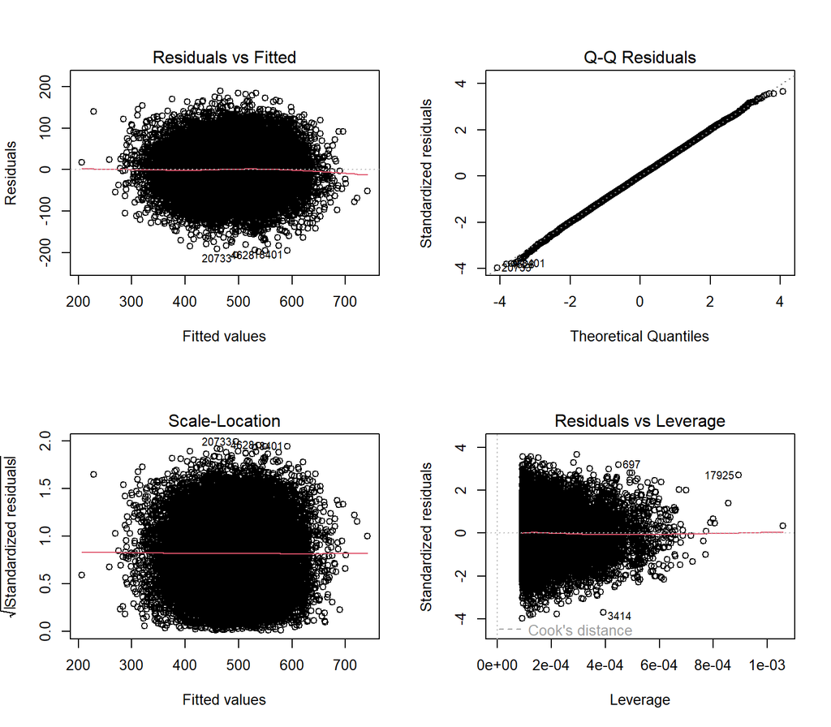

```r
par(mfrow = c(2, 2))
plot(reg_multiple)
```

```r
par(mfrow = c(1, 1))
```

- **Residuals vs Fitted:** Comprueba linealidad y homocedasticidad.
- **Q-Q plot:** Evalúa la normalidad de los residuos.
- **Scale-Location:** Segunda comprobación de homocedasticidad.
- **Residuals vs Leverage:** Detecta observaciones con alta influencia.

# 9 Comprobación de multicolinealidad

```r
library(car)
vif(reg_multiple)
```

```
##   genero    heduc    lectu
## 1.018818 1.020015 1.037874
```

Todos los VIF son muy inferiores a 10, por lo que **no existe multicolinealidad problemática** entre los predictores.

# 10 Conclusiones